# Project: Investigate a Dataset (TMDB Movie dataset)

- Introduction
- Data Wrangling
- Exploratory Data Analysis
- Conclusions

## Introduction

In this project,I have chosen the TDMB movies dataset.  
In this section we will import the required packages.

Following questions can be analysed from the selected dataset:

1. Which genres are most popular(top 10 genres)?
2. Which movie has the highest and lowest budgets?
3. Which movie has the most and least earned revenu?
4. What is the average runtime of movie?
5. What is the average budget of movie?
6. What is the average revenue of the movie?
7. Which movie has the most and least profit?
8. Which movie has the highest and lowest vote_average ?
9. What is the average vote_avearge of movie?
10. Which cast has done the most of the movies?
11. Which production has done the most of the movies?
12. Which production has make the most profit?
13. Which rating has make the most money?

```python
# Use this cell to set up import statements for all of the packages that you
#   plan to use.

# Remember to include a 'magic word' so that your visualizations are plotted
#   inline with the notebook. See this page for more:
#   http://ipython.readthedocs.io/en/stable/interactive/magics.html

import pandas as pd
import numpy as np
import matplotlib.pyplot as plt
from datetime import datetime
import seaborn as sns
%matplotlib inline
```

## Data Wrangling

In this section of the report,we will load in the data, check for cleanliness, and then trim and clean our dataset for analysis.

### General Properties

```python
# Load your data and print out a few lines. Perform operations to inspect data
#   types and look for instances of missing or possibly errant data.

# Load data from tmdb-movies.csv
df = pd.read_csv('tmdb-movies.csv')
```

```python
#Loading the 5 values from the top of the dataset
df.head()
```

|  | id | imdb_id | popularity | budget | revenue | original_title | cast | homepage | director | tagline | ... | overview | runtime | genres | production_companies | release_date | vote_count | vote_average | release_year | budget_adj | revenue_adj |
| --- | --- | --- | --- | --- | --- | --- | --- | --- | --- | --- | --- | --- | --- | --- | --- | --- | --- | --- | --- | --- | --- |
| 0 | 135397 | tt0369610 | 32.985763 | 150000000 | 1513528810 | Jurassic World | Chris Pratt\|Bryce Dallas Howard\|Irrfan Khan\|Vi... | http://www.jurassicworld.com/ | Colin Trevorrow | The park is open. | ... | Twenty-two years after the events of Jurassic ... | 124 | Action\|Adventure\|Science Fiction\|Thriller | Universal Studios\|Amblin Entertainment\|Legenda... | 6/9/15 | 5562 | 6.5 | 2015 | 1.379999e+08 | 1.392446e+09 |
| 1 | 76341 | tt1392190 | 28.419936 | 150000000 | 378436354 | Mad Max: Fury Road | Tom Hardy\|Charlize Theron\|Hugh Keays-Byrne\|Nic... | http://www.madmaxmovie.com/ | George Miller | What a Lovely Day. | ... | An apocalyptic story set in the furthest reach... | 120 | Action\|Adventure\|Science Fiction\|Thriller | Village Roadshow Pictures\|Kennedy Miller Produ... | 5/13/15 | 6185 | 7.1 | 2015 | 1.379999e+08 | 3.481613e+08 |
| 2 | 262500 | tt2908446 | 13.112507 | 110000000 | 295238201 | Insurgent | Shailene Woodley\|Theo James\|Kate Winslet\|Ansel... | http://www.thedivergentseries.movie/#insurgent | Robert Schwentke | One Choice Can Destroy You | ... | Beatrice Prior must confront her inner demons ... | 119 | Adventure\|Science Fiction\|Thriller | Summit Entertainment\|Mandeville Films\|Red Wago... | 3/18/15 | 2480 | 6.3 | 2015 | 1.012000e+08 | 2.716190e+08 |
| 3 | 140607 | tt2488496 | 11.173104 | 200000000 | 2068178225 | Star Wars: The Force Awakens | Harrison Ford\|Mark Hamill\|Carrie Fisher\|Adam D... | http://www.starwars.com/films/star-wars-episod... | J.J. Abrams | Every generation has a story. | ... | Thirty years after defeating the Galactic Empi... | 136 | Action\|Adventure\|Science Fiction\|Fantasy | Lucasfilm\|Truenorth Productions\|Bad Robot | 12/15/15 | 5292 | 7.5 | 2015 | 1.839999e+08 | 1.902723e+09 |
| 4 | 168259 | tt2820852 | 9.335014 | 190000000 | 1506249360 | Furious 7 | Vin Diesel\|Paul Walker\|Jason Statham\|Michelle ... | http://www.furious7.com/ | James Wan | Vengeance Hits Home | ... | Deckard Shaw seeks revenge against Dominic Tor... | 137 | Action\|Crime\|Thriller | Universal Pictures\|Original Film\|Media Rights ... | 4/1/15 | 2947 | 7.3 | 2015 | 1.747999e+08 | 1.385749e+09 |

5 rows × 21 columns

```python
#No. of colmuns and rows
print('Orignal Dataframe contains {} rows and {} columns'.format(df.shape[0],df.shape[1]))
```

```
Orignal Dataframe contains 10866 rows and 21 columns
```

```python
df.describe()
```

|  | id | popularity | budget | revenue | runtime | vote_count | vote_average | release_year | budget_adj | revenue_adj |
| --- | --- | --- | --- | --- | --- | --- | --- | --- | --- | --- |
| count | 10866.000000 | 10866.000000 | 1.086600e+04 | 1.086600e+04 | 10866.000000 | 10866.000000 | 10866.000000 | 10866.000000 | 1.086600e+04 | 1.086600e+04 |
| mean | 66064.177434 | 0.646441 | 1.462570e+07 | 3.982332e+07 | 102.070863 | 217.389748 | 5.974922 | 2001.322658 | 1.755104e+07 | 5.136436e+07 |
| std | 92130.136561 | 1.000185 | 3.091321e+07 | 1.170035e+08 | 31.381405 | 575.619058 | 0.935142 | 12.812941 | 3.430616e+07 | 1.446325e+08 |
| min | 5.000000 | 0.000065 | 0.000000e+00 | 0.000000e+00 | 0.000000 | 10.000000 | 1.500000 | 1960.000000 | 0.000000e+00 | 0.000000e+00 |
| 25% | 10596.250000 | 0.207583 | 0.000000e+00 | 0.000000e+00 | 90.000000 | 17.000000 | 5.400000 | 1995.000000 | 0.000000e+00 | 0.000000e+00 |
| 50% | 20669.000000 | 0.383856 | 0.000000e+00 | 0.000000e+00 | 99.000000 | 38.000000 | 6.000000 | 2006.000000 | 0.000000e+00 | 0.000000e+00 |
| 75% | 75610.000000 | 0.713817 | 1.500000e+07 | 2.400000e+07 | 111.000000 | 145.750000 | 6.600000 | 2011.000000 | 2.085325e+07 | 3.369710e+07 |
| max | 417859.000000 | 32.985763 | 4.250000e+08 | 2.781506e+09 | 900.000000 | 9767.000000 | 9.200000 | 2015.000000 | 4.250000e+08 | 2.827124e+09 |

Checking colmuns which consist null values

```python
df.info()
```

```
<class 'pandas.core.frame.DataFrame'>
RangeIndex: 10866 entries, 0 to 10865
Data columns (total 21 columns):
 #   Column                Non-Null Count  Dtype
---  ------                --------------  -----
 0   id                    10866 non-null  int64
 1   imdb_id               10856 non-null  object
 2   popularity            10866 non-null  float64
 3   budget                10866 non-null  int64
 4   revenue               10866 non-null  int64
 5   original_title        10866 non-null  object
 6   cast                  10790 non-null  object
 7   homepage              2936 non-null   object
 8   director              10822 non-null  object
 9   tagline               8042 non-null   object
 10  keywords              9373 non-null   object
 11  overview              10862 non-null  object
 12  runtime               10866 non-null  int64
 13  genres                10843 non-null  object
 14  production_companies  9836 non-null   object
 15  release_date          10866 non-null  object
 16  vote_count            10866 non-null  int64
 17  vote_average          10866 non-null  float64
 18  release_year          10866 non-null  int64
 19  budget_adj            10866 non-null  float64
 20  revenue_adj           10866 non-null  float64
dtypes: float64(4), int64(6), object(11)
memory usage: 1.7+ MB
```

Checking Unique values

```python
df.nunique()
```

```
id                      10865
imdb_id                 10855
popularity              10814
budget                    557
revenue                  4702
original_title          10571
cast                    10719
homepage                 2896
director                 5067
tagline                  7997
keywords                 8804
overview                10847
runtime                   247
genres                   2039
production_companies     7445
release_date             5909
vote_count               1289
vote_average               72
release_year               56
budget_adj               2614
revenue_adj              4840
dtype: int64
```

### Data Cleaning

> **1.Removing the columns that are not required**

```python
# After discussing the structure of the data and any problems that need to be
#   cleaned, perform those cleaning steps in the second part of this section.

#list of columb to be deleted
del_col=[ 'id', 'imdb_id', 'budget_adj', 'revenue_adj', 'homepage', 'keywords', 'overview', 'vote_count', 'tagline']

#deleting the columns
df= df.drop(del_col,1)

#preview of the new dataset
df.head()
```

|  | popularity | budget | revenue | original_title | cast | director | runtime | genres | production_companies | release_date | vote_average | release_year |
| --- | --- | --- | --- | --- | --- | --- | --- | --- | --- | --- | --- | --- |
| 0 | 32.985763 | 150000000 | 1513528810 | Jurassic World | Chris Pratt\|Bryce Dallas Howard\|Irrfan Khan\|Vi... | Colin Trevorrow | 124 | Action\|Adventure\|Science Fiction\|Thriller | Universal Studios\|Amblin Entertainment\|Legenda... | 6/9/15 | 6.5 | 2015 |
| 1 | 28.419936 | 150000000 | 378436354 | Mad Max: Fury Road | Tom Hardy\|Charlize Theron\|Hugh Keays-Byrne\|Nic... | George Miller | 120 | Action\|Adventure\|Science Fiction\|Thriller | Village Roadshow Pictures\|Kennedy Miller Produ... | 5/13/15 | 7.1 | 2015 |
| 2 | 13.112507 | 110000000 | 295238201 | Insurgent | Shailene Woodley\|Theo James\|Kate Winslet\|Ansel... | Robert Schwentke | 119 | Adventure\|Science Fiction\|Thriller | Summit Entertainment\|Mandeville Films\|Red Wago... | 3/18/15 | 6.3 | 2015 |
| 3 | 11.173104 | 200000000 | 2068178225 | Star Wars: The Force Awakens | Harrison Ford\|Mark Hamill\|Carrie Fisher\|Adam D... | J.J. Abrams | 136 | Action\|Adventure\|Science Fiction\|Fantasy | Lucasfilm\|Truenorth Productions\|Bad Robot | 12/15/15 | 7.5 | 2015 |
| 4 | 9.335014 | 190000000 | 1506249360 | Furious 7 | Vin Diesel\|Paul Walker\|Jason Statham\|Michelle ... | James Wan | 137 | Action\|Crime\|Thriller | Universal Pictures\|Original Film\|Media Rights ... | 4/1/15 | 7.3 | 2015 |

```python
#No. of colmuns and rows
print('New Dataframe contains {} rows and {} columns'.format(df.shape[0],df.shape[1]))
```

```
New Dataframe contains 10866 rows and 12 columns
```

> **2.Removing the duplicated values**

```python
print('Duplicated Rows: {} '.format(sum(df.duplicated())))
```

```
Duplicated Rows: 1
```

```python
df.drop_duplicates(inplace=True)
print('Checking the Duplicated Rows if exists: {} '.format(sum(df.duplicated())))
```

```
Checking the Duplicated Rows if exists: 0
```

> **3. Replace the zero values to NAN in the Revenue, Budget and Runtime column.And after that removing it**

```python
# Creating a seperate list of revenue , budget and runtime column
tem_list=['budget', 'revenue', 'runtime']

#this will replace all the value from '0' to NAN
df[tem_list] = df[tem_list].replace(0, np.NAN)

#Removing all the row which has NaN value in temp_list
df.dropna(subset = tem_list, inplace = True)

print('New Dataframe contains {} rows and {} columns'.format(df.shape[0],df.shape[1]))
```

```
New Dataframe contains 3854 rows and 12 columns
```

> **4. Checking the data format of the columns of the dataset.**

```python
df.dtypes
```

```
popularity              float64
budget                  float64
revenue                 float64
original_title           object
cast                     object
director                 object
runtime                 float64
genres                   object
production_companies     object
release_date             object
vote_average            float64
release_year              int64
dtype: object
```

> Changing the Data type of the budget, revenue and runtime from 'float64' to 'int64'

```python
d_type=['budget', 'revenue','runtime']
#changing data type
df[d_type]=df[d_type].applymap(np.int64)
#printing the changed information
df.dtypes
```

```
popularity              float64
budget                    int64
revenue                   int64
original_title           object
cast                     object
director                 object
runtime                   int64
genres                   object
production_companies     object
release_date             object
vote_average            float64
release_year              int64
dtype: object
```

> Changing the Data type of the release date from 'object' to 'datetime'

```python
df['release_date']=pd.to_datetime(df['release_date'])
```

```python
df.dtypes
```

```
popularity                     float64
budget                           int64
revenue                          int64
original_title                  object
cast                            object
director                        object
runtime                          int64
genres                          object
production_companies            object
release_date            datetime64[ns]
vote_average                   float64
release_year                     int64
dtype: object
```

```python
df.head()
```

|  | popularity | budget | revenue | original_title | cast | director | runtime | genres | production_companies | release_date | vote_average | release_year |
| --- | --- | --- | --- | --- | --- | --- | --- | --- | --- | --- | --- | --- |
| 0 | 32.985763 | 150000000 | 1513528810 | Jurassic World | Chris Pratt\|Bryce Dallas Howard\|Irrfan Khan\|Vi... | Colin Trevorrow | 124 | Action\|Adventure\|Science Fiction\|Thriller | Universal Studios\|Amblin Entertainment\|Legenda... | 2015-06-09 | 6.5 | 2015 |
| 1 | 28.419936 | 150000000 | 378436354 | Mad Max: Fury Road | Tom Hardy\|Charlize Theron\|Hugh Keays-Byrne\|Nic... | George Miller | 120 | Action\|Adventure\|Science Fiction\|Thriller | Village Roadshow Pictures\|Kennedy Miller Produ... | 2015-05-13 | 7.1 | 2015 |
| 2 | 13.112507 | 110000000 | 295238201 | Insurgent | Shailene Woodley\|Theo James\|Kate Winslet\|Ansel... | Robert Schwentke | 119 | Adventure\|Science Fiction\|Thriller | Summit Entertainment\|Mandeville Films\|Red Wago... | 2015-03-18 | 6.3 | 2015 |
| 3 | 11.173104 | 200000000 | 2068178225 | Star Wars: The Force Awakens | Harrison Ford\|Mark Hamill\|Carrie Fisher\|Adam D... | J.J. Abrams | 136 | Action\|Adventure\|Science Fiction\|Fantasy | Lucasfilm\|Truenorth Productions\|Bad Robot | 2015-12-15 | 7.5 | 2015 |
| 4 | 9.335014 | 190000000 | 1506249360 | Furious 7 | Vin Diesel\|Paul Walker\|Jason Statham\|Michelle ... | James Wan | 137 | Action\|Crime\|Thriller | Universal Pictures\|Original Film\|Media Rights ... | 2015-04-01 | 7.3 | 2015 |

```python
print('Finally the dataset contains {} rows and {} columns'.format(df.shape[0],df.shape[1]))
```

```
Finally the dataset contains 3854 rows and 12 columns
```

```python
# exporting the clean dataset
modifydf_csv = df.to_csv('modifydf_csv.csv')
```

## Exploratory Data Analysis

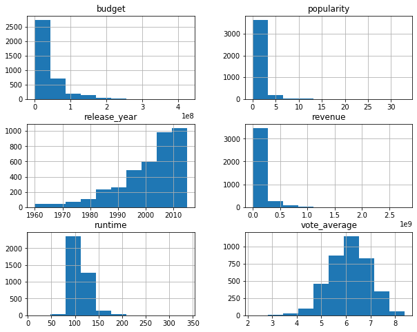

```python
df.hist(figsize=(10,8));
```

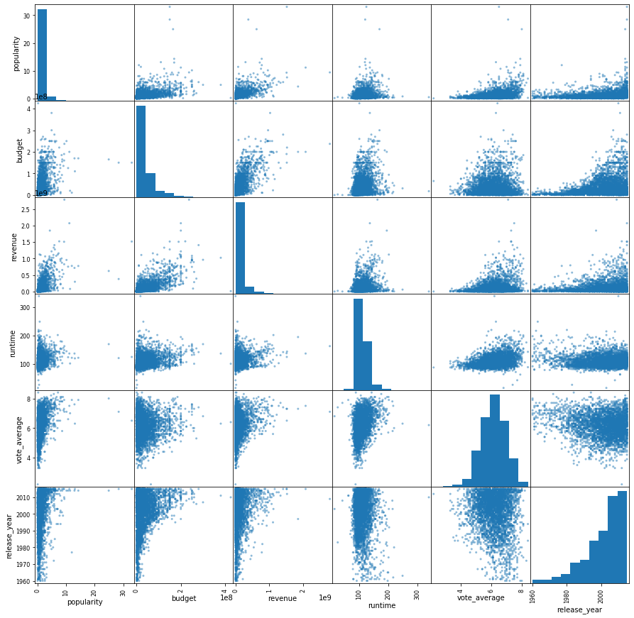

```python
pd.plotting.scatter_matrix(df,figsize=(15,15));
```

### Research Question 1 (Which genres are most popular (top 10 genres)?)

> **Which genres are most popular**

```python
df['genres'].value_counts().idxmax()
```

```
'Drama'
```

```python
df['genres'].value_counts()
```

```
Drama                                      245
Comedy                                     233
Drama|Romance                              107
Comedy|Romance                             104
Comedy|Drama|Romance                        91
                                          ...
Thriller|Drama|Adventure|Action|History      1
Action|Comedy|Western                        1
Drama|Fantasy|Romance|Science Fiction        1
Comedy|Crime|Thriller|Romance                1
Crime|Drama|History|Thriller                 1
Name: genres, Length: 1053, dtype: int64
```

In above result we observed that we have to seprate the genres values that has the format of "Comedy|Drama|Romance" i.e. that has "|" as a seprator between its values.

```python
#The below function is used to seprate the values of genres that have "|" as a seprator
def seprator(col):
    sep_values = df[col].str.cat(sep="|").split("|")
    count_sep_values =pd.Series(sep_values).value_counts(ascending=False)
    return count_sep_values
count_genres= seprator("genres")
count_genres
```

```
Drama              1756
Comedy             1358
Thriller           1204
Action             1085
Adventure           749
Romance             667
Crime               651
Science Fiction     519
Horror              463
Family              425
Fantasy             396
Mystery             344
Animation           201
Music               136
History             129
War                 119
Western              52
Documentary          35
Foreign              13
TV Movie              1
dtype: int64
```

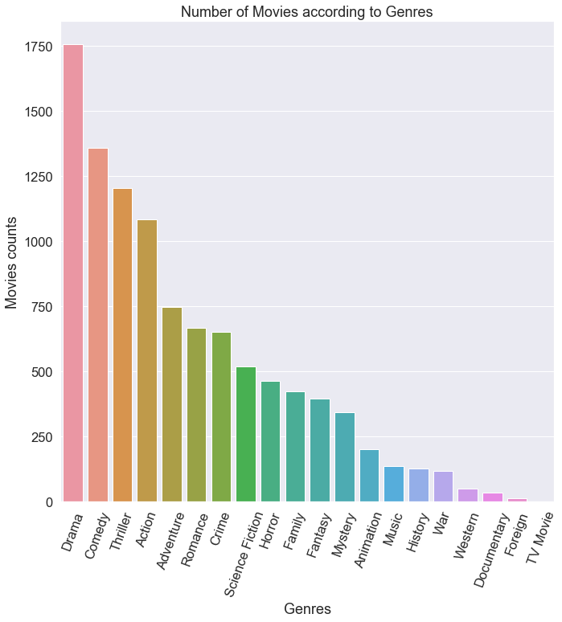

```python
unique_genre = count_genres.sort_values(ascending= False)

#reference:https://seaborn.pydata.org/generated/seaborn.barplot.html

sns.set(rc={'figure.figsize':(11,11)}, font_scale=1.5)
axis = sns.barplot(unique_genre.index, unique_genre)

#rotate x-axis' text
for item in axis.get_xticklabels():
    item.set_rotation(70)

axis.set(xlabel='Genres', ylabel='Movies counts', title = 'Number of Movies according to Genres')
plt.show()
```

We analysed that the top 10 genres are :

1. Drama
2. Comedy
3. Thriller
4. Action
5. Advanture
6. Romance
7. Crime
8. Science Fiction
9. Horror
10. Family

### Research Question 2 (Which movie with largest and lowest budgets?)

```python
# We will use this function many times to find the maximun and minimum values
def find_Max_Min(col):

    #finding the max and min vvalues in the column.
    Max_index=df[col].idxmax()
    Min_index=df[col].idxmin()
    #getting all the related columns of that max and min
    maximum=pd.DataFrame(df.loc[Max_index])
    minimum=pd.DataFrame(df.loc[Min_index])
    result=pd.concat([maximum,minimum],axis=1)
    return result
```

```python
find_Max_Min('budget')
```

|  | 2244 | 2618 |
| --- | --- | --- |
| popularity | 0.25054 | 0.090186 |
| budget | 425000000 | 1 |
| revenue | 11087569 | 100 |
| original_title | The Warrior's Way | Lost & Found |
| cast | Kate Bosworth\|Jang Dong-gun\|Geoffrey Rush\|Dann... | David Spade\|Sophie Marceau\|Ever Carradine\|Step... |
| director | Sngmoo Lee | Jeff Pollack |
| runtime | 100 | 95 |
| genres | Adventure\|Fantasy\|Action\|Western\|Thriller | Comedy\|Romance |
| production_companies | Boram Entertainment Inc. | Alcon Entertainment\|Dinamo Entertainment |
| release_date | 2010-12-02T00:00:00.000000000 | 1999-04-23T00:00:00.000000000 |
| vote_average | 6.4 | 4.8 |
| release_year | 2010 | 1999 |

We analysed that the Column id with 2244 has the highest value in budget i.e. 425 million dollars (Movie : The Warrior's Way) whereas the column id with 2618 has the lowest value in budget i.e. 1 dollar (Movie : Lost & Found)

### Research Question 3 (Which movie has the most and least earned revenu?)

```python
find_Max_Min('revenue')
```

|  | 1386 | 5067 |
| --- | --- | --- |
| popularity | 9.43277 | 0.462609 |
| budget | 237000000 | 6000000 |
| revenue | 2781505847 | 2 |
| original_title | Avatar | Shattered Glass |
| cast | Sam Worthington\|Zoe Saldana\|Sigourney Weaver\|S... | Hayden Christensen\|Peter Sarsgaard\|ChloÃ« Sevi... |
| director | James Cameron | Billy Ray |
| runtime | 162 | 94 |
| genres | Action\|Adventure\|Fantasy\|Science Fiction | Drama\|History |
| production_companies | Ingenious Film Partners\|Twentieth Century Fox ... | Lions Gate Films\|Cruise/Wagner Productions\|Bau... |
| release_date | 2009-12-10T00:00:00.000000000 | 2003-11-14T00:00:00.000000000 |
| vote_average | 7.1 | 6.4 |
| release_year | 2009 | 2003 |

We analysed that the Column id with 1386 is the highest in revenue i.e. 2.78 billion dollars (Movie : Avatar) while its budget is 237 million dollars whereas the column id with 5067 is the lowest in revenue i.e. 2 dollars dollar while it's budget is 6 million dollars (Movie: Shattered Glass).

### Research Question 4 (What is the average runtime of movie?)

```python
#Creating a avgerage to calculate averages
def find_average(column):
    return df[column].mean()
```

```python
find_average('runtime')
```

```
109.22029060716139
```

The average duration of the movie is 109.22 minutes.

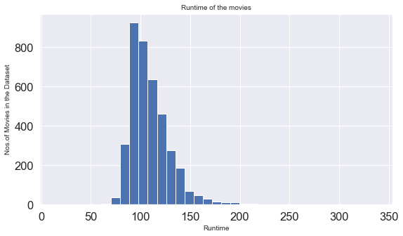

```python
#plotting a histogram of runtime of movies

#giving the figure size(width, height)
plt.figure(figsize=(9,5))

plt.xlabel('Runtime', fontsize = 10)
plt.ylabel('Nos.of Movies in the Dataset', fontsize=10)
plt.title('Runtime of the movies', fontsize=10)

plt.hist(df['runtime'],bins =35)
plt.show();
```

### Research Question 5 (What is the average budget of movie?)

```python
find_average('budget')
```

```
37203696.954852104
```

The average budget is 37.2 million dollars.

### Research Question 6 (What is the average revenue of the movie?)

```python
find_average('revenue')
```

```
107686616.09807992
```

The average revenue is 107.6 million dollars.

### Research Question 7 (Which movie had most and least profit?)

Now to calculate the profit we need to substracte the budget from revenue and add the resultant in the orignal dataframe.

```python
df['profit']=df['revenue']-df['budget']
```

```python
find_Max_Min('profit')
```

|  | 1386 | 2244 |
| --- | --- | --- |
| popularity | 9.43277 | 0.25054 |
| budget | 237000000 | 425000000 |
| revenue | 2781505847 | 11087569 |
| original_title | Avatar | The Warrior's Way |
| cast | Sam Worthington\|Zoe Saldana\|Sigourney Weaver\|S... | Kate Bosworth\|Jang Dong-gun\|Geoffrey Rush\|Dann... |
| director | James Cameron | Sngmoo Lee |
| runtime | 162 | 100 |
| genres | Action\|Adventure\|Fantasy\|Science Fiction | Adventure\|Fantasy\|Action\|Western\|Thriller |
| production_companies | Ingenious Film Partners\|Twentieth Century Fox ... | Boram Entertainment Inc. |
| release_date | 2009-12-10T00:00:00.000000000 | 2010-12-02T00:00:00.000000000 |
| vote_average | 7.1 | 6.4 |
| release_year | 2009 | 2010 |
| profit | 2544505847 | -413912431 |

Note: Here positive value shows the profit while the negative value shows the loss

We analysed that Avatar has earned the highest profit i.e. 2.54 billion dollars and The Warrior's Way has the lowest profit i.e. loss of 413.9 million dollars.

```python
find_Max_Min('vote_average')
```

|  | 4178 | 4859 |
| --- | --- | --- |
| popularity | 7.19204 | 0.111351 |
| budget | 25000000 | 65000000 |
| revenue | 28341469 | 73706 |
| original_title | The Shawshank Redemption | Foodfight! |
| cast | Tim Robbins\|Morgan Freeman\|Bob Gunton\|William ... | Charlie Sheen\|Wayne Brady\|Hilary Duff\|Eva Long... |
| director | Frank Darabont | Lawrence Kasanoff |
| runtime | 142 | 87 |
| genres | Drama\|Crime | Animation\|Action\|Comedy\|Family |
| production_companies | Castle Rock Entertainment | Threshold Entertainment\|Lions Gate Family Ente... |
| release_date | 1994-09-10T00:00:00.000000000 | 2012-06-15T00:00:00.000000000 |
| vote_average | 8.4 | 2.2 |
| release_year | 1994 | 2012 |
| profit | 3341469 | -64926294 |

The Shawshank Redemption has the highest votes i.e. 8.4 whereas Foodfight! has the lowest i.e. 2.2.

### Research Question 9(What is the average vote_average of movie?)

```python
find_average('vote_average')
```

```
6.168162947586924
```

We analysed that 6.17 is the average votes.

### Research Question 10(Which cast has done the most of the movies?)

```python
count_casts= seprator("cast")
count_casts.head()
```

```
Robert De Niro       52
Bruce Willis         46
Samuel L. Jackson    44
Nicolas Cage         43
Matt Damon           36
dtype: int64
```

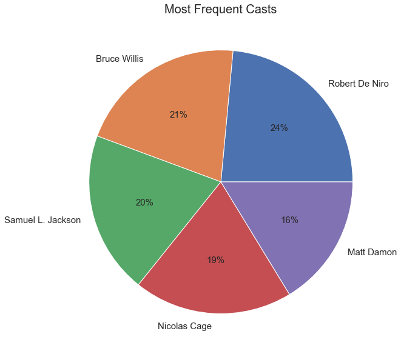

```python
count_casts = count_casts[0:5]
plt.figure(figsize=(10,10))
casts_pie=count_casts.plot.pie(fontsize=15,autopct='%1.0f%%')
plt.title('Most Frequent Casts',fontsize=20)
plt.ylabel('');
```

We analysed that the most of the movies were done by Robert De Niro, Bruce Willis, Samuel L. Jackson, Nicolas Cage and Matt Damon respectively.

### Research Question 11(Which production has done the most of the movies?)

```python
count_productions= seprator("production_companies")
count_productions.head(10)
```

```
Universal Pictures                        329
Warner Bros.                              324
Paramount Pictures                        270
Twentieth Century Fox Film Corporation    201
Columbia Pictures                         178
New Line Cinema                           152
Walt Disney Pictures                      117
Touchstone Pictures                       116
Metro-Goldwyn-Mayer (MGM)                 109
Relativity Media                          102
dtype: int64
```

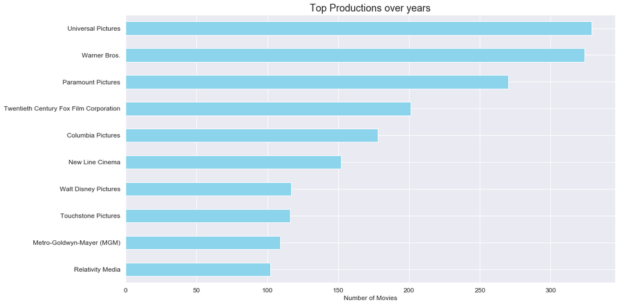

```python
count_productions=count_productions[0:10]
plt.figure(figsize=(16,9))
production_chart=count_productions.plot.barh(fontsize=12,color='#8Cd4eB')
plt.gca().invert_yaxis()
plt.title('Top Productions over years',fontsize=(18))
plt.xlabel('Number of Movies',fontsize=(12));
```

We analysed that the most of the movies were produced by respectively. Universal Pictures, Warner Bros.,Paramount Pictures,  
Twentieth Century Fox Film Corporation, Columbia Pictures, New Line Cinema, Walt Disney Pictures, Touchstone Pictures,Metro-Goldwyn-Mayer (MGM), Relativity Media.

### Research Question 12(Which production has make the most profit?)

```python
def group_profit(col):
        data=df.groupby(col).sum().profit
        return data
```

```python
categorical_production = group_profit("production_companies")
categorical_production
```

```
production_companies
10th Hole Productions|Benaroya Pictures|Four of a Kind Productions                                   -4376180
120dB Films|Scion Films|Voodoo Production Services|Chydzik Media Group|First Wedding Productions         1377
1492 Pictures|Dune Entertainment|Fox 2000 Pictures|Sunswept Entertainment|Dune Entertainment III     84578751
1492 Pictures|Warner Bros.|Heyday Films                                                             851475550
1492 Pictures|Warner Bros.|Heyday Films|MIRACLE Productions GmbH & Co. KG                           776688482
                                                                                                      ...
area japan                                                                                          -14683000
chateau productions                                                                                         0
erbp                                                                                                   344098
iDeal Partners Film Fund                                                                             -3944875
icon                                                                                                 -1330097
Name: profit, Length: 3008, dtype: int64
```

[figure not shown]

```python
#reference:https://seaborn.pydata.org/generated/seaborn.barplot.html
categorical_production= categorical_production.sort_values(ascending= False)[0:20]
sns.set(rc={'figure.figsize':(21,11)}, font_scale=1.5)
axis = sns.barplot(categorical_production.index,categorical_production)

#rotate x-axis' text
for item in axis.get_xticklabels():
    item.set_rotation(85)

axis.set(xlabel='Production', ylabel='Movies counts', title = 'Movies with respect to Production')
plt.show()
```

```python
profit, max_production = categorical_production.max(), categorical_production.idxmax()
print("The {} production company have make the highest profit i.e. {} profit.".format(max_production,profit))
```

```
The Walt Disney Pictures|Pixar Animation Studios production company have make the highest profit i.e. 5791558520 profit.
```

### Research Question 13(Which voting has make the most money?)

```python
categorical_votes= group_profit("vote_average")
categorical_votes
```

```
vote_average
2.2      -64926294
3.3      -37580562
3.4       73683745
3.5      -21923806
3.6       33362772
3.7       14044182
3.8      -42209010
3.9       60695606
4.0     -103454163
4.1      -13969280
4.2      159556198
4.3       57581642
4.4      168906943
4.5      100801987
4.6      193758977
4.7      474420483
4.8      191635815
4.9      221546438
5.0      860394187
5.1     1684774422
5.2     1788983517
5.3     3343830584
5.4     2550218279
5.5     5823901132
5.6     8084012068
5.7     5984640136
5.8     9987308932
5.9     8767139972
6.0    10751567115
6.1    14492546281
6.2    11838758597
6.3    11935939574
6.4    15639459720
6.5    17195696278
6.6    15107218277
6.7     8718189181
6.8    11018697235
6.9    12553516381
7.0    11433197946
7.1    12580557077
7.2    10159482353
7.3    13421006324
7.4     9191825116
7.5    10076171890
7.6     5878604033
7.7     5436973175
7.8     4373480928
7.9     4914569711
8.0     2308240041
8.1     2017458348
8.2       10693093
8.3      239066411
8.4        7120391
Name: profit, dtype: int64
```

[figure not shown]

```python
#reference:https://seaborn.pydata.org/generated/seaborn.barplot.html

sns.set(rc={'figure.figsize':(21,11)}, font_scale=1.5)
axis = sns.barplot(categorical_votes.index,categorical_votes)

#rotate x-axis' text
for item in axis.get_xticklabels():
    item.set_rotation(70)

axis.set(xlabel='Votes Average', ylabel='Movies counts', title = 'Movies with respect to Average Votes')
plt.show()
```

```python
max_profit, vote= categorical_votes.max(), categorical_votes.idxmax()
print("The {} voted movies have make {} profit.".format(vote, max_profit))
```

```
The 6.5 voted movies have make 17195696278 profit.
```

## Conclusions

We came up with the following analysis:

Limitations:

1. We have dropped many rows with mssing values , hence a lot of information is also lost in that process
2. Budget and Revenue do not have currency unit therefore we assumed it as dollars. It may also lead to futher errors because every country has its own currency which varies in foreign countries.
3. We have also dropped many columns in the beginning that might helped later.